# Google Play Store DataAnalysis

```python
import numpy as np
import pandas as pd
import matplotlib.pyplot as plt
import seaborn as sns
%matplotlib inline
```

# Data Collection

```python
df = pd.read_csv(r"C:\Users\HP\Documents\Nareshit\Pandas\EDA\dataset\Google-Playstore.csv")
df.head()
```

|  | App Name | App Id | Category | Rating | Rating Count | Installs | Minimum Installs | Maximum Installs | Free | Price | ... | Developer Website | Developer Email | Released | Last Updated | Content Rating | Privacy Policy | Ad Supported | In App Purchases | Editors Choice | Scraped Time |
| --- | --- | --- | --- | --- | --- | --- | --- | --- | --- | --- | --- | --- | --- | --- | --- | --- | --- | --- | --- | --- | --- |
| 0 | Gakondo | com.ishakwe.gakondo | Adventure | 0.0 | 0.0 | 10+ | 10.0 | 15 | True | 0.0 | ... | https://beniyizibyose.tk/#/ | jean21101999@gmail.com | Feb 26, 2020 | Feb 26, 2020 | Everyone | https://beniyizibyose.tk/projects/ | False | False | False | 2021-06-15 20:19:35 |
| 1 | Ampere Battery Info | com.webserveis.batteryinfo | Tools | 4.4 | 64.0 | 5,000+ | 5000.0 | 7662 | True | 0.0 | ... | https://webserveis.netlify.app/ | webserveis@gmail.com | May 21, 2020 | May 06, 2021 | Everyone | https://dev4phones.wordpress.com/licencia-de-uso/ | True | False | False | 2021-06-15 20:19:35 |
| 2 | Vibook | com.doantiepvien.crm | Productivity | 0.0 | 0.0 | 50+ | 50.0 | 58 | True | 0.0 | ... | NaN | vnacrewit@gmail.com | Aug 9, 2019 | Aug 19, 2019 | Everyone | https://www.vietnamairlines.com/vn/en/terms-an... | False | False | False | 2021-06-15 20:19:35 |
| 3 | Smart City Trichy Public Service Vehicles 17UC... | cst.stJoseph.ug17ucs548 | Communication | 5.0 | 5.0 | 10+ | 10.0 | 19 | True | 0.0 | ... | http://www.climatesmarttech.com/ | climatesmarttech2@gmail.com | Sep 10, 2018 | Oct 13, 2018 | Everyone | NaN | True | False | False | 2021-06-15 20:19:35 |
| 4 | GROW.me | com.horodyski.grower | Tools | 0.0 | 0.0 | 100+ | 100.0 | 478 | True | 0.0 | ... | http://www.horodyski.com.pl | rmilekhorodyski@gmail.com | Feb 21, 2020 | Nov 12, 2018 | Everyone | http://www.horodyski.com.pl | False | False | False | 2021-06-15 20:19:35 |

5 rows × 24 columns

# Data Cleaning

```python
df.head(5)
```

|  | App Name | App Id | Category | Rating | Rating Count | Installs | Minimum Installs | Maximum Installs | Free | Price | ... | Developer Website | Developer Email | Released | Last Updated | Content Rating | Privacy Policy | Ad Supported | In App Purchases | Editors Choice | Scraped Time |
| --- | --- | --- | --- | --- | --- | --- | --- | --- | --- | --- | --- | --- | --- | --- | --- | --- | --- | --- | --- | --- | --- |
| 0 | Gakondo | com.ishakwe.gakondo | Adventure | 0.0 | 0.0 | 10+ | 10.0 | 15 | True | 0.0 | ... | https://beniyizibyose.tk/#/ | jean21101999@gmail.com | Feb 26, 2020 | Feb 26, 2020 | Everyone | https://beniyizibyose.tk/projects/ | False | False | False | 2021-06-15 20:19:35 |
| 1 | Ampere Battery Info | com.webserveis.batteryinfo | Tools | 4.4 | 64.0 | 5,000+ | 5000.0 | 7662 | True | 0.0 | ... | https://webserveis.netlify.app/ | webserveis@gmail.com | May 21, 2020 | May 06, 2021 | Everyone | https://dev4phones.wordpress.com/licencia-de-uso/ | True | False | False | 2021-06-15 20:19:35 |
| 2 | Vibook | com.doantiepvien.crm | Productivity | 0.0 | 0.0 | 50+ | 50.0 | 58 | True | 0.0 | ... | NaN | vnacrewit@gmail.com | Aug 9, 2019 | Aug 19, 2019 | Everyone | https://www.vietnamairlines.com/vn/en/terms-an... | False | False | False | 2021-06-15 20:19:35 |
| 3 | Smart City Trichy Public Service Vehicles 17UC... | cst.stJoseph.ug17ucs548 | Communication | 5.0 | 5.0 | 10+ | 10.0 | 19 | True | 0.0 | ... | http://www.climatesmarttech.com/ | climatesmarttech2@gmail.com | Sep 10, 2018 | Oct 13, 2018 | Everyone | NaN | True | False | False | 2021-06-15 20:19:35 |
| 4 | GROW.me | com.horodyski.grower | Tools | 0.0 | 0.0 | 100+ | 100.0 | 478 | True | 0.0 | ... | http://www.horodyski.com.pl | rmilekhorodyski@gmail.com | Feb 21, 2020 | Nov 12, 2018 | Everyone | http://www.horodyski.com.pl | False | False | False | 2021-06-15 20:19:35 |

5 rows × 24 columns

```python
df.shape
```

```
(2312944, 24)
```

```python
df.isnull().sum()
# mean , median , mode , dropna , ffill , bfill
# if the null <5% then use dropna
# if the column category -> mode
# if the column has extreme values(outliers) -> median
# if the columns has numeric (normal values) -> mean
# if the column is time based then -> ffill/bfill
```

```
App Name                  5
App Id                    0
Category                  0
Rating                22883
Rating Count          22883
Installs                107
Minimum Installs        107
Maximum Installs          0
Free                      0
Price                     0
Currency                135
Size                    196
Minimum Android        6530
Developer Id             33
Developer Website    760835
Developer Email          31
Released              71053
Last Updated              0
Content Rating            0
Privacy Policy       420953
Ad Supported              0
In App Purchases          0
Editors Choice            0
Scraped Time              0
dtype: int64
```

```python
df.dtypes
```

```
App Name              object
App Id                object
Category              object
Rating               float64
Rating Count         float64
Installs              object
Minimum Installs     float64
Maximum Installs       int64
Free                    bool
Price                float64
Currency              object
Size                  object
Minimum Android       object
Developer Id          object
Developer Website     object
Developer Email       object
Released              object
Last Updated          object
Content Rating        object
Privacy Policy        object
Ad Supported            bool
In App Purchases        bool
Editors Choice          bool
Scraped Time          object
dtype: object
```

```python
 df.fillna(df['Rating'].mean(), inplace = True)
```

```python
df['Rating'].isnull().sum()
```

```
np.int64(0)
```

```python
# Before filling null value
df['Rating Count'].skew()
df['Rating Count'].plot(kind='hist')
```

```python
df.fillna(df['Rating Count'].median(), inplace = True)
```

[figure not shown]

```python
plt.boxplot(df['Rating'])
plt.show()
```

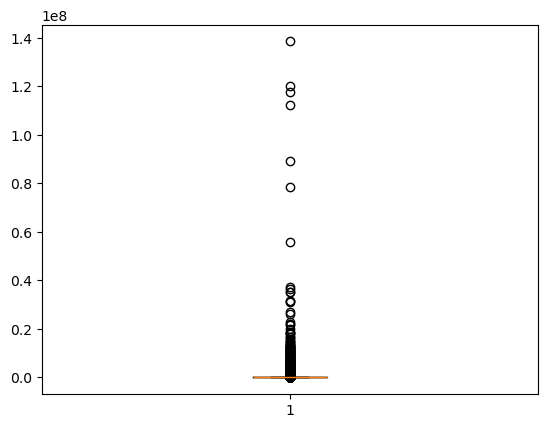

```python
plt.boxplot(df['Rating Count'])
plt.show()
```

```python
df.columns
```

```
Index(['App Name', 'App Id', 'Category', 'Rating', 'Rating Count', 'Installs',
       'Minimum Installs', 'Maximum Installs', 'Free', 'Price', 'Currency',
       'Size', 'Minimum Android', 'Developer Id', 'Developer Website',
       'Developer Email', 'Released', 'Last Updated', 'Content Rating',
       'Privacy Policy', 'Ad Supported', 'In App Purchases', 'Editors Choice',
       'Scraped Time'],
      dtype='object')
```

```python
df.dropna(subset = ['App Name','Installs', 'Minimum Installs' , 'Currency' , 'Size' , 'Developer Id' , 'Developer Website' , 'Developer Email'] , inplace = True)
```

```python
df.isnull().sum()
```

```
App Name             0
App Id               0
Category             0
Rating               0
Rating Count         0
Installs             0
Minimum Installs     0
Maximum Installs     0
Free                 0
Price                0
Currency             0
Size                 0
Minimum Android      0
Developer Id         0
Developer Website    0
Developer Email      0
Released             0
Last Updated         0
Content Rating       0
Privacy Policy       0
Ad Supported         0
In App Purchases     0
Editors Choice       0
Scraped Time         0
dtype: int64
```

# Looking for Duplicate

```python
df['App Name'].duplicated().any()
```

```
np.True_
```

```python
df['App Name'].value_counts()
```

```
App Name
Tic Tac Toe                         382
Calculator                          261
Flashlight                          256
BMI Calculator                      201
Age Calculator                      190
                                   ...
STMIK Mercusuar - Aditya Rachman      1
Lero TOEFL Recorder + Timer           1
大俠客—熱血歸來                              1
ORU Online                            1
Gluten-free Recipes                   1
Name: count, Length: 2177944, dtype: int64
```

```python
# select Tic Tac Toe app

df[df['App Name']== 'Tic Tac Toe' ]
```

|  | App Name | App Id | Category | Rating | Rating Count | Installs | Minimum Installs | Maximum Installs | Free | Price | ... | Developer Website | Developer Email | Released | Last Updated | Content Rating | Privacy Policy | Ad Supported | In App Purchases | Editors Choice | Scraped Time |
| --- | --- | --- | --- | --- | --- | --- | --- | --- | --- | --- | --- | --- | --- | --- | --- | --- | --- | --- | --- | --- | --- |
| 3918 | Tic Tac Toe | com.dev.atte.tic_tac_toe | Puzzle | 0.0 | 0.0 | 10+ | 10.0 | 30 | True | 0.0 | ... | https://ne2ad32ee.app-ads-txt.com | dev.atte.francois@gmail.com | May 18, 2018 | May 18, 2018 | Everyone | 2.203152 | True | False | False | 2021-06-15 20:23:22 |
| 13758 | Tic Tac Toe | com.md.tictactoe | Board | 0.0 | 0.0 | 10+ | 10.0 | 31 | True | 0.0 | ... | 2.203152 | msms.zaman@gmail.com | Nov 2, 2020 | Nov 18, 2020 | Everyone | https://smartdailytools.blogspot.com/2020/09/p... | True | False | False | 2021-06-15 20:32:58 |
| 25351 | Tic Tac Toe | com.sthirumuru.tictactoenew | Board | 4.2 | 11.0 | 5,000+ | 5000.0 | 6379 | True | 0.0 | ... | 2.203152 | sundeep.thirumuru@gmail.com | Apr 13, 2021 | Jun 03, 2021 | Everyone | 2.203152 | True | False | False | 2021-06-15 20:44:27 |
| 28142 | Tic Tac Toe | com.fsk00x.TicTacToe | Board | 0.0 | 0.0 | 500+ | 500.0 | 922 | True | 0.0 | ... | 2.203152 | devmethyl@outlook.com | Feb 13, 2020 | Feb 13, 2020 | Everyone | 2.203152 | True | False | False | 2021-06-15 20:47:17 |
| 30962 | Tic Tac Toe | net.snatchdreams.tictactoe | Puzzle | 0.0 | 0.0 | 10+ | 10.0 | 38 | True | 0.0 | ... | https://www.snatchdreams.net | snatchdreams@gmail.com | Jul 16, 2017 | Oct 16, 2019 | Everyone | https://www.snatchdreams.net/privacy/tic-tac-toe/ | True | False | False | 2021-06-15 20:50:12 |
| ... | ... | ... | ... | ... | ... | ... | ... | ... | ... | ... | ... | ... | ... | ... | ... | ... | ... | ... | ... | ... | ... |
| 2272773 | Tic Tac Toe | com.tictactoe.MobileAppsPro | Board | 3.8 | 9269.0 | 500,000+ | 500000.0 | 800662 | True | 0.0 | ... | 2.203152 | smartyka@gmail.com | Jan 9, 2015 | May 20, 2015 | Everyone | http://mobileappspro.yolasite.com | True | False | False | 2021-06-16 12:23:56 |
| 2281376 | Tic Tac Toe | com.erjainam.tictactoe.release | Board | 0.0 | 0.0 | 50+ | 50.0 | 50 | True | 0.0 | ... | https://erjainam.com | engineerjainam@gmail.com | Sep 2, 2018 | Sep 02, 2018 | Everyone | https://docs.google.com/document/d/1Tyi5D3VxZu... | True | False | False | 2021-06-16 12:31:30 |
| 2282023 | Tic Tac Toe | com.swapworld.tic_tac_toe | Board | 4.7 | 7.0 | 10+ | 10.0 | 34 | True | 0.0 | ... | http://prudhvikchirunomula.pythonanywhere.com/ | prudhvik.1996@gmail.com | Sep 4, 2019 | Sep 17, 2019 | Everyone | 2.203152 | False | False | False | 2021-06-16 12:32:05 |
| 2299121 | Tic Tac Toe | com.infuse.tictactoe | Board | 4.8 | 20.0 | 100+ | 100.0 | 462 | True | 0.0 | ... | http://www.infuseapps.com | infuseandroidapps@gmail.com | Jan 18, 2015 | Jan 18, 2015 | Everyone | 2.203152 | True | False | False | 2021-06-16 12:47:11 |
| 2310375 | Tic Tac Toe | com.justmailtoavi.avinashk.threet | Puzzle | 4.7 | 10.0 | 100+ | 100.0 | 173 | True | 0.0 | ... | 2.203152 | justmailtoavi@gmail.com | Mar 30, 2016 | Apr 01, 2016 | Everyone | 2.203152 | False | False | False | 2021-06-16 12:57:05 |

382 rows × 24 columns

**Observation**

- Although all of our apps have the same name, they are differentiated by their unique app identifiers.

```python
df.columns
```

```
Index(['App Name', 'App Id', 'Category', 'Rating', 'Rating Count', 'Installs',
       'Minimum Installs', 'Maximum Installs', 'Free', 'Price', 'Currency',
       'Size', 'Minimum Android', 'Developer Id', 'Developer Website',
       'Developer Email', 'Released', 'Last Updated', 'Content Rating',
       'Privacy Policy', 'Ad Supported', 'In App Purchases', 'Editors Choice',
       'Scraped Time'],
      dtype='object')
```

```python
df['Installs'].unique()
```

```
array(['10+', '5,000+', '50+', '100+', '1,000+', '500+', '50,000+',
       '10,000+', '1+', '500,000+', '100,000+', '5+', '10,000,000+',
       '1,000,000+', '5,000,000+', '0+', '100,000,000+',
       np.float64(2.203151531771424), '50,000,000+', '1,000,000,000+',
       '500,000,000+', '5,000,000,000+', '10,000,000,000+'], dtype=object)
```

```python
df['Installs'] = df['Installs'].str.replace('+','', regex=False).str.replace(',','', regex=False)
```

```python
import pandas as pd
df['Installs'] = pd.to_numeric(df['Installs'], errors='coerce')
```

```python
df['Installs'].unique()
```

```
array([1.e+01, 5.e+03, 5.e+01, 1.e+02, 1.e+03, 5.e+02, 5.e+04, 1.e+04,
       1.e+00, 5.e+05, 1.e+05, 5.e+00, 1.e+07, 1.e+06, 5.e+06, 0.e+00,
       1.e+08,    nan, 5.e+07, 1.e+09, 5.e+08, 5.e+09, 1.e+10])
```

```python
# print(1.e+01)
```

**Dealing with Size columns**

```python
df['Size'].unique()
```

```
array(['10M', '2.9M', '3.7M', ..., '405M', '3.2k', '512M'], dtype=object)
```

```python
df['Size'].value_counts()
```

```
Size
Varies with device    74777
11M                   62157
12M                   56080
13M                   48034
14M                   45211
                      ...
470M                      1
910M                      1
959M                      1
3.2k                      1
512M                      1
Name: count, Length: 1658, dtype: int64
```

```python
df['Size'] =  df['Size'].str.replace('M' , '000000')
df['Size'] =  df['Size'].str.replace('K' , '000')
df['Size'] =  df['Size'].str.replace('G' , '000000000')
```

```python
df['Size'] = pd.to_numeric(df['Size'], errors='coerce')
```

```python
df['Size'].unique()
```

```
array([1.00e+07, 2.90e+00, 3.70e+00, 1.80e+00, 6.20e+00, 4.60e+07,
       2.50e+00, 1.60e+07, 1.30e+00, 3.50e+00, 5.10e+07, 2.70e+00,
       7.60e+00, 1.50e+07, 2.90e+07, 1.20e+07, 2.00e+00, 7.00e+07,
       1.10e+07, 2.40e+07, 1.40e+00, 2.00e+07, 2.40e+00, 2.50e+07,
       2.10e+07, 3.60e+07, 6.10e+00, 2.60e+00, 8.90e+00, 3.90e+00,
       3.00e+07, 2.60e+07, 4.90e+00, 4.30e+00, 4.80e+00, 4.60e+00,
       2.80e+00, 3.80e+07, 5.10e+00, 1.47e+08, 3.30e+07, 2.20e+00,
       7.10e+00, 2.70e+07, 1.80e+07, 7.70e+00, 3.20e+07, 1.90e+07,
       3.90e+07, 3.10e+07, 1.20e+00, 3.10e+00, 3.20e+00, 4.20e+07,
       2.20e+07, 4.10e+00, 5.00e+07, 5.50e+00,      nan, 8.40e+00,
       4.10e+07, 4.90e+07, 7.00e+00, 4.70e+00, 4.30e+07, 5.40e+00,
       3.00e+00, 1.60e+00, 2.10e+00, 3.70e+07, 3.60e+00, 9.00e+00,
       9.90e+00, 6.70e+07, 2.80e+07, 7.90e+00, 3.30e+00, 6.00e+00,
       5.70e+00, 9.80e+00, 5.00e+00, 1.70e+00, 7.40e+00, 1.90e+00,
       3.80e+00, 6.40e+00, 8.10e+00, 6.50e+00, 4.40e+00, 4.50e+07,
       7.20e+00, 1.30e+07, 6.90e+00, 6.00e+07, 6.60e+00, 4.00e+00,
       1.70e+07, 4.20e+00, 5.80e+07, 9.30e+07, 9.70e+00, 2.30e+07,
       5.20e+07, 5.60e+00, 4.80e+07, 1.50e+00, 8.50e+00, 5.40e+07,
       6.20e+07, 1.33e+08, 6.40e+07, 1.52e+08, 1.36e+08, 9.50e+00,
       4.50e+00, 4.00e+07, 8.00e+00, 2.30e+00, 3.50e+07, 8.30e+07,
       7.30e+00, 6.70e+00, 9.40e+00, 6.90e+07, 7.50e+00, 8.40e+07,
       5.90e+00, 6.30e+00, 3.40e+07, 6.30e+07, 3.40e+00, 5.70e+07,
       1.40e+07, 8.60e+07, 9.20e+00, 1.42e+08, 6.80e+00, 9.10e+00,
       9.60e+00, 4.40e+07, 1.00e+00, 5.30e+07, 9.10e+07, 6.10e+07,
       5.20e+00, 5.30e+00, 8.30e+00, 8.20e+00, 7.90e+07, 9.30e+00,
       4.70e+07, 1.07e+08, 8.60e+00, 9.50e+07, 5.60e+07, 5.80e+00,
       7.10e+07, 7.80e+07, 7.80e+00, 5.90e+07, 7.20e+07, 8.70e+00,
       7.50e+07, 1.51e+08, 1.45e+08, 8.80e+00, 8.20e+07, 1.00e+01,
       6.60e+07, 1.01e+08, 7.60e+07, 9.60e+07, 1.39e+08, 1.25e+08,
       1.11e+08, 1.10e+00, 1.16e+08, 9.40e+07, 9.90e+07, 8.90e+07,
       5.50e+07, 8.50e+07, 9.80e+07, 1.22e+08, 8.80e+07, 7.70e+07,
       1.06e+08, 8.70e+07, 9.70e+07, 2.01e+08, 6.80e+07, 1.18e+08,
       7.40e+07, 7.30e+07, 1.44e+08, 2.50e+08, 8.10e+07, 1.12e+08,
       6.50e+07, 1.02e+08, 1.05e+08, 1.00e+08, 1.13e+08, 5.31e+08,
       1.20e+08, 1.41e+08, 1.30e+08, 9.20e+07, 9.00e+07, 1.50e+08,
       8.00e+07, 1.56e+08, 1.21e+08, 1.43e+08, 1.37e+08, 1.59e+08,
       4.22e+08, 1.49e+08, 1.34e+08, 1.15e+08, 1.28e+08, 2.30e+08,
       1.03e+08, 1.46e+08, 1.14e+08, 1.38e+08, 1.17e+08, 1.10e+08,
       1.58e+08, 1.48e+08, 1.27e+08, 1.09e+08, 1.53e+08, 1.62e+08,
       1.19e+08, 1.32e+08, 1.65e+08, 1.04e+08, 1.40e+08, 1.23e+08,
```

[output cut: 46 more lines]

```
       3.71e+08, 3.96e+08, 3.77e+08, 8.96e+08, 4.15e+08, 4.68e+08,
       5.90e+08, 3.55e+08, 5.93e+08, 4.24e+08, 6.46e+08, 5.27e+08,
       3.66e+08, 4.88e+08, 3.01e+08, 3.97e+08, 7.45e+08, 4.65e+08,
       5.03e+08, 5.70e+08, 8.69e+08, 3.29e+08, 3.73e+08, 3.40e+08,
       4.08e+08, 3.02e+08, 7.05e+08, 3.69e+08, 4.40e+08, 6.79e+08,
       5.68e+08, 5.19e+08, 5.80e+08, 9.77e+08, 9.59e+08, 9.81e+08,
       2.59e+08, 5.26e+08, 3.79e+08, 6.23e+08, 6.19e+08, 2.78e+08,
       5.21e+08, 3.15e+08, 8.44e+08, 8.89e+08, 9.96e+08, 3.65e+08,
       4.31e+08, 5.81e+08, 3.34e+08, 9.62e+08, 5.41e+08, 7.99e+08,
       3.42e+08, 3.70e+08, 5.32e+08, 3.82e+08, 4.42e+08, 7.37e+08,
       8.66e+08, 3.94e+08, 9.14e+08, 6.91e+08, 7.25e+08, 4.61e+08,
       6.33e+08, 3.49e+08, 7.00e+08, 3.56e+08, 7.20e+08, 7.44e+08,
       4.29e+08, 5.33e+08, 8.10e+08, 4.04e+08, 3.54e+08, 7.69e+08,
       6.92e+08, 8.39e+08, 8.30e+08, 7.12e+08, 4.70e+08, 9.10e+08,
       4.05e+08, 5.12e+08])
```

```python
df['Size'].dtypes
```

```
dtype('float64')
```

```python
df.columns
```

```
Index(['App Name', 'App Id', 'Category', 'Rating', 'Rating Count', 'Installs',
       'Minimum Installs', 'Maximum Installs', 'Free', 'Price', 'Currency',
       'Size', 'Minimum Android', 'Developer Id', 'Developer Website',
       'Developer Email', 'Released', 'Last Updated', 'Content Rating',
       'Privacy Policy', 'Ad Supported', 'In App Purchases', 'Editors Choice',
       'Scraped Time'],
      dtype='object')
```

```python
df['Minimum Android'].unique()
```

```
array(['7.1 and up', '5.0 and up', '4.0.3 and up', '4.1 and up',
       '6.0 and up', '4.4 and up', '4.0 and up', '4.2 and up',
       '2.1 and up', '7.0 and up', '2.2 and up', '2.3 and up',
       '4.3 and up', '5.1 and up', np.float64(2.203151531771424),
       '1.6 and up', '3.0 and up', 'Varies with device', '8.0 and up',
       '2.3.3 and up', '4.4W and up', '3.2 and up', '1.5 and up',
       '4.0.3 - 7.1.1', '3.1 and up', '2.0 and up', '1.0 and up',
       '1.1 and up', '2.0.1 and up', '4.4 - 6.0', '2.1 - 4.4',
       '4.0 - 5.0', '2.0 - 2.3.4', '2.2 - 4.4', '4.1 - 7.0', '4.1 - 6.0',
       '4.0 - 4.4W', '4.0 - 4.4', '4.0.3 - 7.0', '2.3 - 5.0',
       '4.0 - 7.1.1', '4.1 - 7.1.1', '4.0 - 7.0', '4.1 - 8.0',
       '4.0 - 6.0', '2.3 - 7.0', '4.0 - 8.0', '2.3 - 6.0', '2.1 - 2.3.4',
       '3.0 - 4.1.1', '2.2 - 3.0', '2.0 - 8.0', '4.0.3 - 8.0',
       '3.0 - 4.4W', '4.4 - 7.1.1', '4.4 - 8.0', '4.0.3 - 6.0',
       '1.6 - 4.0.4', '8.0', '2.3 - 5.1', '2.1 - 7.1.1', '2.3 - 4.4W',
       '4.4 - 7.0', '6.0 - 7.1.1', '2.3 - 4.4', '2.2 - 4.0.4',
       '2.1 - 4.1.1', '3.0 - 8.0', '3.0 - 5.1', '2.1 - 6.0', '6.0 - 8.0',
       '5.0 - 8.0', '4.1 - 5.1', '3.2 - 4.4', '2.1 - 5.0', '4.1 - 4.3',
       '5.0 - 6.0', '5.1 - 7.1.1', '2.2 - 5.1', '4.1 - 5.0',
       '2.3.3 - 4.4', '2.2 - 5.0', '2.2', '4.1 - 4.4', '1.6 - 5.1',
       '4.2 - 7.1.1', '2.1 - 5.1', '1.6 - 4.4W', '4.3 - 4.4W',
       '3.0 - 4.4', '2.1 - 3.1', '2.3 - 7.1.1', '1.6 - 4.0.2',
       '4.0 - 4.0.4', '4.2 - 4.4W', '3.0 - 7.1.1', '3.2 - 7.1.1',
       '3.0 - 6.0', '2.2 - 4.4W', '4.0.3 - 4.4', '4.0.3 - 5.1', '6.0',
       '4.3', '1.1 - 4.4', '2.3.3 - 8.0', '2.3.3 - 5.0', '2.2 - 6.0',
       '3.0 - 5.0', '2.3.3 - 2.3.4', '1.5 - 2.1', '2.2 - 3.2',
       '5.0 - 7.1.1', '2.1 - 3.2', '4.2 - 4.2.2', '2.3.3 - 5.1',
       '2.2 - 4.1.1', '1.6 - 4.4', '4.2 - 4.3', '4.0 - 5.1', '1.6 - 7.0',
       '3.0 - 7.0', '1.0 - 6.0', '2.3.3 - 4.0.4', '2.3 - 3.2',
       '4.3 - 8.0', '2.3 - 8.0', '3.2 - 6.0', '2.3.3 - 7.1.1',
       '4.2 - 8.0', '2.2 - 4.3', '3.2 - 4.1.1', '4.4 - 5.1',
       '2.3 - 4.1.1', '2.1 - 4.4W', '4.4', '2.3.3 - 4.4W', '4.1 - 4.4W',
       '1.6 - 7.1.1', '2.2 - 4.2.2', '4.3 - 5.1', '4.0.3 - 4.2.2',
       '2.2 - 2.3.4', '4.3 - 4.4', '4.2 - 6.0', '4.4 - 4.4W',
       '2.3 - 4.0.2', '3.2 - 5.1', '7.0', '3.0 - 3.2', '1.6 - 4.2.2',
       '5.1', '1.5 - 3.2', '2.2 - 8.0', '1.6 - 2.1', '2.3.3 - 6.0'],
      dtype=object)
```

```python
df['Minimum Android'].value_counts()
```

```
Minimum Android
4.1 and up      604465
5.0 and up      396998
4.4 and up      390311
4.0.3 and up    180482
4.0 and up      153441
                 ...
5.1                  1
1.5 - 3.2            1
2.2 - 8.0            1
1.6 - 2.1            1
2.3.3 - 6.0          1
Name: count, Length: 155, dtype: int64
```

```python
df['Content Rating'].unique()
```

```
array(['Everyone', 'Teen', 'Mature 17+', 'Everyone 10+',
       'Adults only 18+', 'Unrated'], dtype=object)
```

```python
df['Content Rating']
```

```
0          Everyone
1          Everyone
2          Everyone
3          Everyone
4          Everyone
             ...
2312939        Teen
2312940    Everyone
2312941    Everyone
2312942    Everyone
2312943    Everyone
Name: Content Rating, Length: 2312944, dtype: object
```

```python
df['Released']
```

```
0          Feb 26, 2020
1          May 21, 2020
2           Aug 9, 2019
3          Sep 10, 2018
4          Feb 21, 2020
               ...
2312939        2.203152
2312940    Jan 17, 2018
2312941    Aug 19, 2018
2312942     Aug 1, 2016
2312943     Aug 9, 2019
Name: Released, Length: 2312944, dtype: object
```

```python
df['Last Updated']
```

```
0          Feb 26, 2020
1          May 06, 2021
2          Aug 19, 2019
3          Oct 13, 2018
4          Nov 12, 2018
               ...
2312939    Jun 01, 2021
2312940    Feb 02, 2018
2312941    Aug 19, 2018
2312942    May 05, 2021
2312943    Aug 19, 2019
Name: Last Updated, Length: 2312944, dtype: object
```

- Lets clean the content rating
- Mature 17+ ---------> to Adults
- Adults only 18 -----------> to Adults
- Everyone 10+ ------------> to Teen
- Unrated ---------------> Everyone

```python
df['Content Rating'] = df['Content Rating'].replace('Unrated', 'Everyone')
df['Content Rating'] = df['Content Rating'].replace('Mature 17+', 'Adults')
df['Content Rating'] = df['Content Rating'].replace('Everyone 10+', 'Teen')
df['Content Rating'] = df['Content Rating'].replace('Adults only 18+', 'Adults')
```

```python
df['Content Rating'].unique()
```

```
array(['Everyone', 'Teen', 'Adults'], dtype=object)
```

```python
df.info()
```

```
<class 'pandas.core.frame.DataFrame'>
RangeIndex: 2312944 entries, 0 to 2312943
Data columns (total 24 columns):
 #   Column             Dtype
---  ------             -----
 0   App Name           object
 1   App Id             object
 2   Category           object
 3   Rating             float64
 4   Rating Count       float64
 5   Installs           float64
 6   Minimum Installs   float64
 7   Maximum Installs   int64
 8   Free               bool
 9   Price              float64
```

[output cut: 16 more lines]

```python
df.columns
# df['Rating count'].unique()
```

```
Index(['App Name', 'App Id', 'Category', 'Rating', 'Rating Count', 'Installs',
       'Minimum Installs', 'Maximum Installs', 'Free', 'Price', 'Currency',
       'Size', 'Minimum Android', 'Developer Id', 'Developer Website',
       'Developer Email', 'Released', 'Last Updated', 'Content Rating',
       'Privacy Policy', 'Ad Supported', 'In App Purchases', 'Editors Choice',
       'Scraped Time'],
      dtype='object')
```

```python
df['Rating Count'].unique()
```

```
array([0.0000e+00, 6.4000e+01, 5.0000e+00, ..., 8.7553e+04, 7.5960e+04,
       7.8351e+04])
```

```python
df['Rating Count'].max()
```

```
138557570.0
```

```python
def categorize_rating(x):
    if x < 10000:
        return 'less than 10k'
    elif 10000 <= x <= 500000:
        return '10k to 500k'
    else:
        return 'more than 500k'

df['Rating Category'] = df['Rating Count'].apply(categorize_rating)


df['Rating Category']
```

```
0          less than 10k
1          less than 10k
2          less than 10k
3          less than 10k
4          less than 10k
               ...
2312939      10k to 500k
2312940    less than 10k
2312941    less than 10k
2312942    less than 10k
2312943    less than 10k
Name: Rating Category, Length: 2312944, dtype: object
```

# categorical Analysis

- Q1.According to the count, which 10 categories are there in the Play Store?

```python
df.columns
```

```
Index(['App Name', 'App Id', 'Category', 'Rating', 'Rating Count', 'Installs',
       'Minimum Installs', 'Maximum Installs', 'Free', 'Price', 'Currency',
       'Size', 'Minimum Android', 'Developer Id', 'Developer Website',
       'Developer Email', 'Released', 'Last Updated', 'Content Rating',
       'Privacy Policy', 'Ad Supported', 'In App Purchases', 'Editors Choice',
       'Scraped Time', 'Rating Category'],
      dtype='object')
```

```python
df['Category'].unique()
```

```
array(['Adventure', 'Tools', 'Productivity', 'Communication', 'Social',
       'Libraries & Demo', 'Lifestyle', 'Personalization', 'Racing',
       'Maps & Navigation', 'Travel & Local', 'Food & Drink',
       'Books & Reference', 'Medical', 'Puzzle', 'Entertainment',
       'Arcade', 'Auto & Vehicles', 'Photography', 'Health & Fitness',
       'Education', 'Shopping', 'Board', 'Music & Audio', 'Sports',
       'Beauty', 'Business', 'Educational', 'Finance', 'News & Magazines',
       'Casual', 'Art & Design', 'House & Home', 'Card', 'Events',
       'Trivia', 'Weather', 'Strategy', 'Word', 'Video Players & Editors',
       'Action', 'Simulation', 'Music', 'Dating', 'Role Playing',
       'Casino', 'Comics', 'Parenting'], dtype=object)
```

```python
top_category = df.Category.value_counts().reset_index()
```

```python
top_category.head(10)
```

|  | Category | count |
| --- | --- | --- |
| 0 | Education | 241090 |
| 1 | Music & Audio | 154906 |
| 2 | Tools | 143988 |
| 3 | Business | 143771 |
| 4 | Entertainment | 138276 |
| 5 | Lifestyle | 118331 |
| 6 | Books & Reference | 116728 |
| 7 | Personalization | 89210 |
| 8 | Health & Fitness | 83510 |
| 9 | Productivity | 79698 |

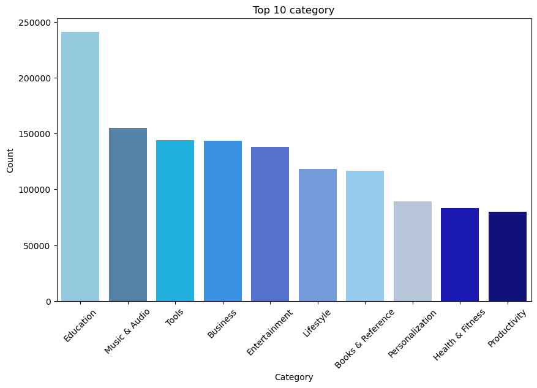

```python
top_10_category = top_category.head(10)
categories = top_10_category['Category']
count = top_10_category['count']

plt.figure(figsize=(10,6))
cols = ['skyblue', 'steelblue', 'deepskyblue', 'dodgerblue', 'royalblue',
          'cornflowerblue', 'lightskyblue', 'lightsteelblue', 'mediumblue', 'darkblue']
sns.barplot(x = categories , y = count ,palette=  cols)
plt.title('Top 10 category')
plt.ylabel('Count')
plt.xticks(rotation = 45)
plt.show()
```

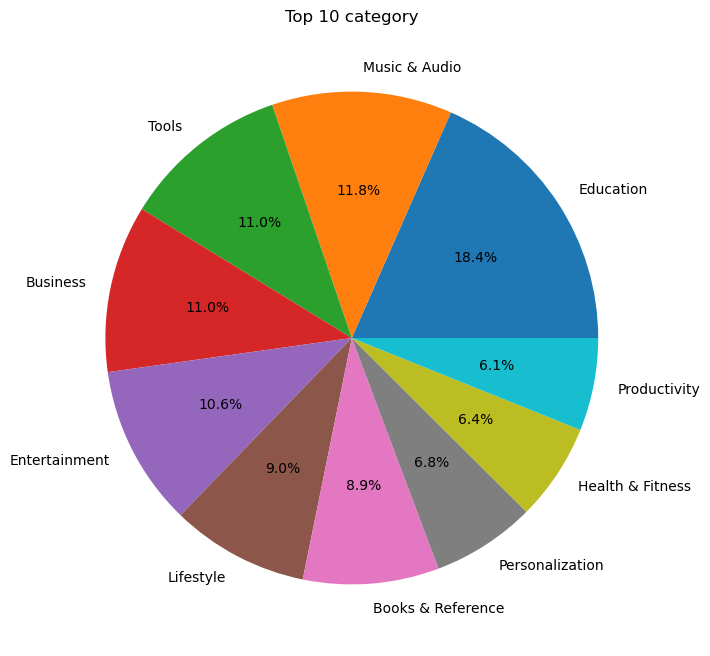

```python
plt.figure(figsize=(8,8))
plt.pie(top_10_category['count'],
       labels=top_10_category['Category'],
       autopct = '%1.1f%%')
plt.title('Top 10 category')
plt.show()
```

- Q2.In what category are the top ten highest ratings?

```python
top_category_rating = df.groupby('Category')['Rating'].mean().reset_index()
top_category_rating = top_category_rating.sort_values(by='Rating' , ascending = False).head(10)
top_category_rating.head(10)
```

|  | Category | Rating |
| --- | --- | --- |
| 36 | Role Playing | 3.340112 |
| 10 | Casino | 3.270987 |
| 38 | Simulation | 3.186735 |
| 46 | Weather | 3.105612 |
| 9 | Card | 3.070818 |
| 35 | Racing | 2.946939 |
| 45 | Video Players & Editors | 2.899342 |
| 47 | Word | 2.893573 |
| 41 | Strategy | 2.855995 |
| 12 | Comics | 2.855426 |

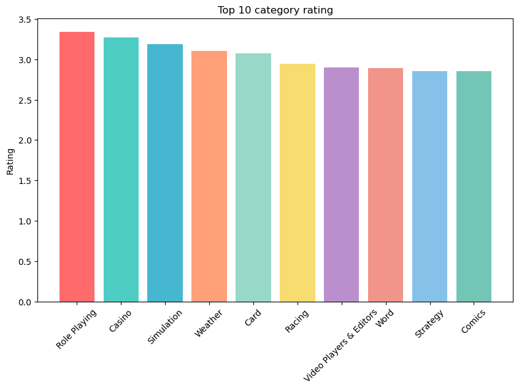

```python
plt.figure(figsize=(10,6))
cols = [
    '#FF6B6B',  # red coral
    '#4ECDC4',  # teal
    '#45B7D1',  # sky blue
    '#FFA07A',  # light salmon
    '#98D8C8',  # mint
    '#F7DC6F',  # yellow
    '#BB8FCE',  # lavender
    '#F1948A',  # soft red
    '#85C1E9',  # light blue
    '#73C6B6'   # aqua green
]
plt.bar(top_category_rating['Category'] , top_category_rating['Rating'],color=  cols)
plt.title('Top 10 category rating')
plt.ylabel('Rating')
plt.xticks(rotation = 45)
plt.show()
```

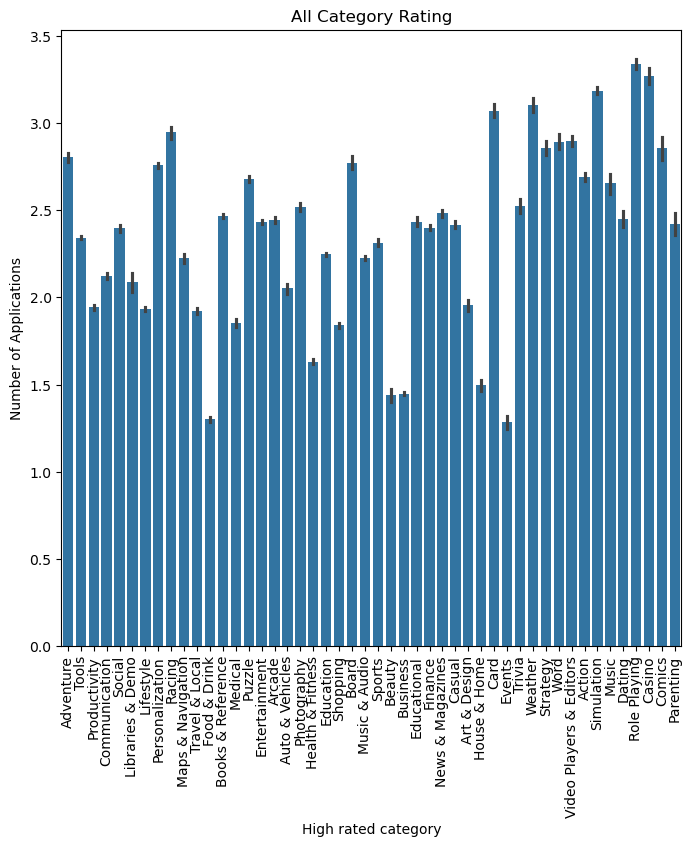

```python
plt.figure(figsize=(8,8))
plt.xticks(rotation = 90)
plt.xlabel('High rated category')
plt.ylabel('Number of Applications')
plt.title('All Category Rating')
sns.barplot(x = df.Category , y = df.Rating)
plt.show()
```

```python
df['Content Rating'].unique()
```

```
array(['Everyone', 'Teen', 'Adults'], dtype=object)
```

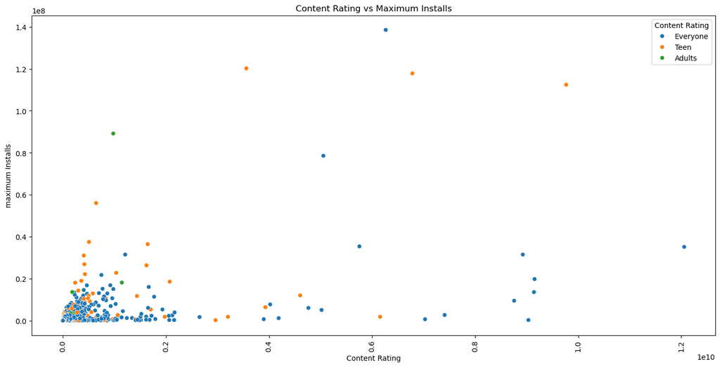

```python
plt.figure(figsize=(17,8))
plt.xticks(rotation = 90)
plt.xlabel('Content Rating')
plt.ylabel('maximum Installs')
plt.title('Content Rating vs Maximum Installs')
sns.scatterplot(data = df ,x = "Maximum Installs" , y = "Rating Count", hue = "Content Rating") # hue -> grouping by content rating
plt.show()
```

- Q3. Which Play Store categories have the most Installs, based on the count?

```python
df['Category'].unique()
```

```
array(['Adventure', 'Tools', 'Productivity', 'Communication', 'Social',
       'Libraries & Demo', 'Lifestyle', 'Personalization', 'Racing',
       'Maps & Navigation', 'Travel & Local', 'Food & Drink',
       'Books & Reference', 'Medical', 'Puzzle', 'Entertainment',
       'Arcade', 'Auto & Vehicles', 'Photography', 'Health & Fitness',
       'Education', 'Shopping', 'Board', 'Music & Audio', 'Sports',
       'Beauty', 'Business', 'Educational', 'Finance', 'News & Magazines',
       'Casual', 'Art & Design', 'House & Home', 'Card', 'Events',
       'Trivia', 'Weather', 'Strategy', 'Word', 'Video Players & Editors',
       'Action', 'Simulation', 'Music', 'Dating', 'Role Playing',
       'Casino', 'Comics', 'Parenting'], dtype=object)
```

```python
Category_installs = df.groupby('Category')['Installs'].sum().reset_index()
top_10_installs =  Category_installs.head(10)
top_10_installs
```

|  | Category | Installs |
| --- | --- | --- |
| 0 | Action | 1.740038e+10 |
| 1 | Adventure | 5.390120e+09 |
| 2 | Arcade | 1.450133e+10 |
| 3 | Art & Design | 1.116399e+09 |
| 4 | Auto & Vehicles | 1.594746e+09 |
| 5 | Beauty | 4.043288e+08 |
| 6 | Board | 3.290827e+09 |
| 7 | Books & Reference | 4.820201e+09 |
| 8 | Business | 5.236670e+09 |
| 9 | Card | 1.989329e+09 |

[figure not shown]

```python
plt.figure(figsize=(10,6))
cols = [
    '#FF6B6B',  # red coral
    '#4ECDC4',  # teal
    '#45B7D1',  # sky blue
    '#FFA07A',  # light salmon
    '#98D8C8',  # mint
    '#F7DC6F',  # yellow
    '#BB8FCE',  # lavender
    '#F1948A',  # soft red
    '#85C1E9',  # light blue
    '#73C6B6'   # aqua green
]
plt.bar(top_10_installs['Category'] , top_10_installs['Installs'],color=  cols)
plt.title('Top 10 Most Install Category')
plt.ylabel('Installs')
plt.xticks(rotation = 45)
plt.show()
```

```python
top_category_installs = pd.merge(top_category ,top_10_installs , on = 'Category' )
top_category_installs.head(10)
```

|  | Category | count | Installs |
| --- | --- | --- | --- |
| 0 | Business | 143771 | 5.236670e+09 |
| 1 | Books & Reference | 116728 | 4.820201e+09 |
| 2 | Arcade | 53792 | 1.450133e+10 |
| 3 | Action | 27555 | 1.740038e+10 |
| 4 | Adventure | 23203 | 5.390120e+09 |
| 5 | Art & Design | 18539 | 1.116399e+09 |
| 6 | Auto & Vehicles | 18280 | 1.594746e+09 |
| 7 | Beauty | 11772 | 4.043288e+08 |
| 8 | Board | 10588 | 3.290827e+09 |
| 9 | Card | 8179 | 1.989329e+09 |

```python
top_category_installs = top_category_installs.sort_values(by='Installs' , ascending = False).head(10)
top_10_installs
```

|  | Category | Installs |
| --- | --- | --- |
| 0 | Action | 1.740038e+10 |
| 1 | Adventure | 5.390120e+09 |
| 2 | Arcade | 1.450133e+10 |
| 3 | Art & Design | 1.116399e+09 |
| 4 | Auto & Vehicles | 1.594746e+09 |
| 5 | Beauty | 4.043288e+08 |
| 6 | Board | 3.290827e+09 |
| 7 | Books & Reference | 4.820201e+09 |
| 8 | Business | 5.236670e+09 |
| 9 | Card | 1.989329e+09 |

[figure not shown]

```python
plt.figure(figsize=(10,8))
plt.title('Top 10 most Installs category')
plt.xlabel('Category')
plt.ylabel('Installs')
plt.bar(top_category_installs['Category'],top_category_installs['Installs'], color = cols)
plt.xticks(rotation = 45)
plt.show()
```

[figure not shown]

```python
plt.figure(figsize=(8,8))
plt.pie(top_category_installs['Installs'],
       labels=top_category_installs['Category'],
       autopct = '%1.1f%%')
plt.title('Top 10 Most Installs Category')
plt.show()
```

- Q4. What category has the most popular free and paid apps?

```python
df.columns
```

```
Index(['App Name', 'App Id', 'Category', 'Rating', 'Rating Count', 'Installs',
       'Minimum Installs', 'Maximum Installs', 'Free', 'Price', 'Currency',
       'Size', 'Minimum Android', 'Developer Id', 'Developer Website',
       'Developer Email', 'Released', 'Last Updated', 'Content Rating',
       'Privacy Policy', 'Ad Supported', 'In App Purchases', 'Editors Choice',
       'Scraped Time', 'Rating Category'],
      dtype='object')
```

```python
df['Free'].unique()
```

```
array([ True, False])
```

```python
df['Price'].unique()
```

```
array([ 0.      ,  1.99    ,  4.99    , ...,  3.041816, 26.746362,
       18.903596])
```

```python
df.groupby('Category')['Price'].value_counts().reset_index(name = 'Count').sort_values(by='Count' , ascending = False).head(10)
```

|  | Category | Price | Count |
| --- | --- | --- | --- |
| 806 | Education | 0.0 | 234543 |
| 2038 | Music & Audio | 0.0 | 153382 |
| 481 | Business | 0.0 | 143101 |
| 2936 | Tools | 0.0 | 139911 |
| 1192 | Entertainment | 0.0 | 136894 |
| 1585 | Lifestyle | 0.0 | 116989 |
| 292 | Books & Reference | 0.0 | 113131 |
| 2189 | Personalization | 0.0 | 83443 |
| 1422 | Health & Fitness | 0.0 | 82097 |
| 2348 | Productivity | 0.0 | 77967 |

```python
df['Free'] = df['Price'] == 0
df['Free'] = df['Free'].replace({True:'Free' , False : 'Paid'})
# df['Free']
```

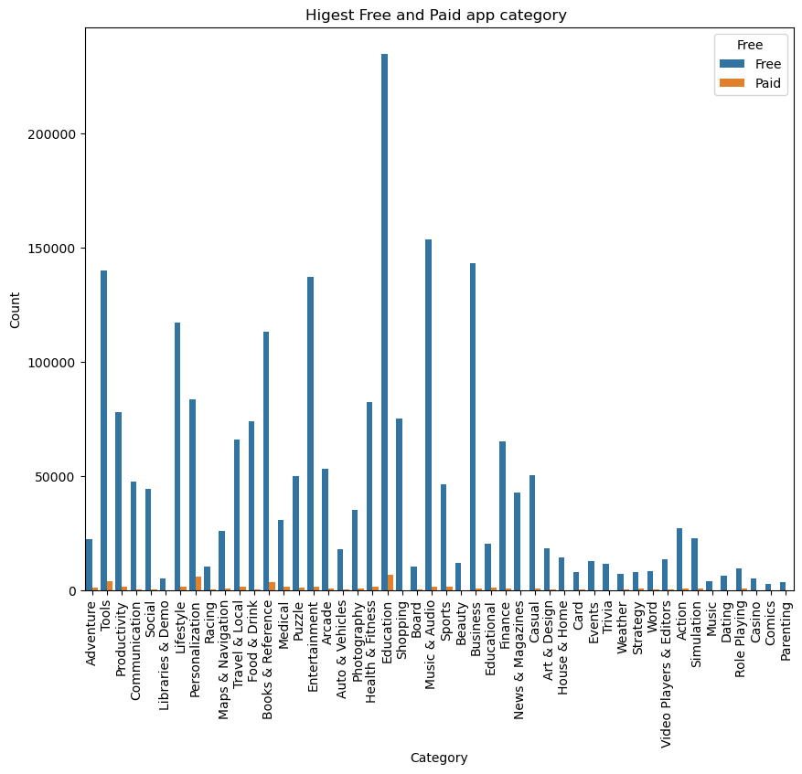

```python
plt.figure(figsize=(10,8))
plt.xlabel('Category')
plt.ylabel('Count')
plt.title('Higest Free and Paid app category ')
plt.xticks(rotation = 90)
sns.countplot(x='Category' , data = df, hue='Free')
plt.show()
```

```python
df['Free'].value_counts()
```

[output not shown]

```python
df['Free'].unique()
```

```
array(['Free', 'Paid'], dtype=object)
```

- Q4.What category has the highest number of free and paid app installations?

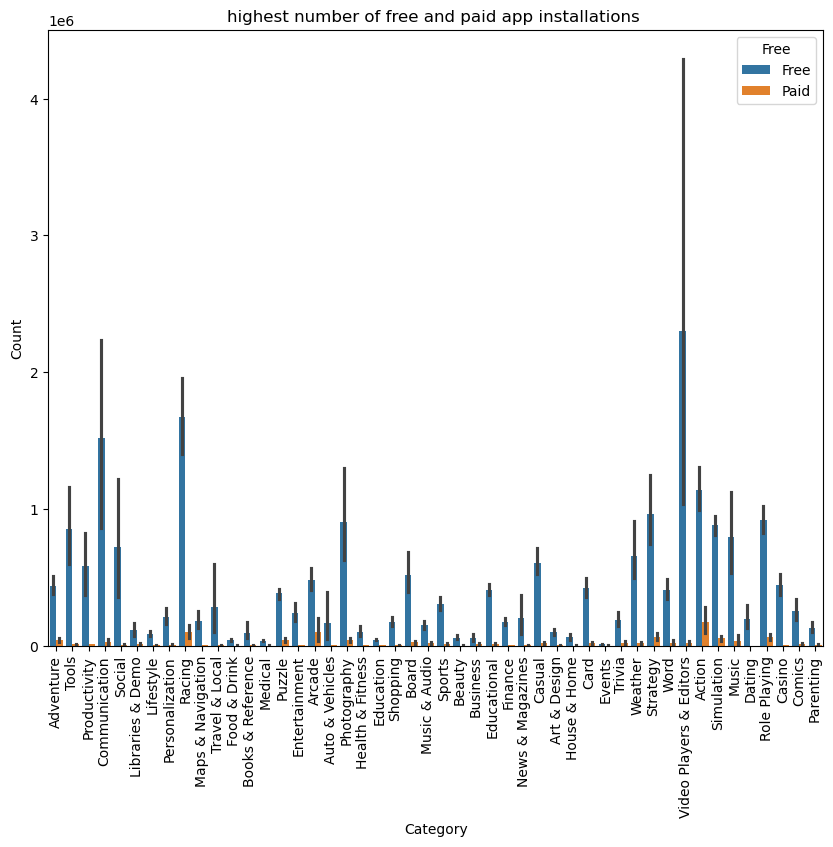

```python
plt.figure(figsize=(10,8))
plt.xlabel('Category')
plt.ylabel('Count')
plt.title('highest number of free and paid app installations ')
plt.xticks(rotation = 90)
sns.barplot(x='Category' , y = 'Maximum Installs', data = df, hue='Free')
plt.show()
```

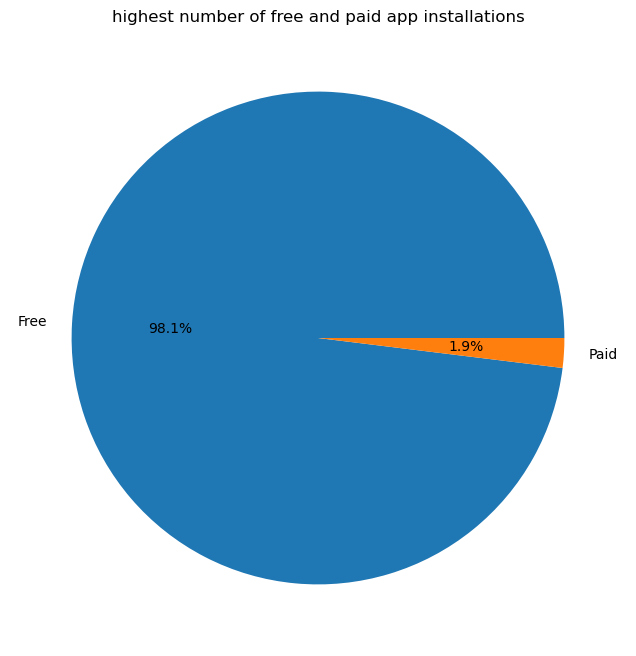

```python
plt.figure(figsize=(8,8))
plt.pie(df['Free'].value_counts(),
       labels=['Free' , 'Paid'],
       autopct = '%1.1f%%')
plt.title('highest number of free and paid app installations')
plt.show()
```

## 📌 Conclusion

In this project, we performed a comprehensive Exploratory Data Analysis (EDA) on the app dataset to understand patterns, trends, and relationships between different features.

Overall, this EDA provided valuable insights into user behavior, app popularity, and market trends, which can be useful for decision-making and building predictive models in the future.